# Statistics for Bioengineering - Week 1

# Tidy Data & File Types

## An Example to Get Started

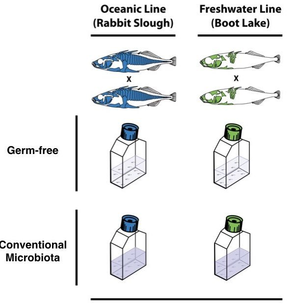

Source: Photo illustration

## What is Tidy Data?

| Term | Definition | Example |
| --- | --- | --- |
| *Measurement* | A single piece of recorded information reflecting a characteristic of interest (e.g. length of a leaf, pH of a water aliquot, mass of an individual, number of individuals per quadrat etc) | Protein content of the milk of a single female koala |
| *Observation* | A single measured sampling or experimental unit (such as an individual, a quadrat, a site etc) | A small quantity of milk from a single koala |
| *Population* | All the possible observations that could be measured and the unit of which wish to draw conclusions about (note a statistical population need not be a viable biological population) | The milk of all female koalas |
| *Sample* | The (representative) subset of the population that are observed | A small quantity of milk collected from 15 captive female koalas<sup>a</sup> |
| *Variable* | A set of measurements of the same type that comprise the sample. The characteristic that differs (varies) from observation to observation | The protein content of koala milk. |

## What is Tidy Data?

Different formats may be appropriate for different applications, but one is particularly convenient for data science: **tidy data**.

**The Three Principles of Tidy Data**

1. **One observation per row** — All measurements for a single unit
2. **One variable per column** — Something measured across all units
3. **One type of observation per data set**

New observations can easily be added as rows, and new variables as columns.

## Tidy Data Set Rules of Thumb

- Store data in nonproprietary formats (plain ASCII text / flat files)
- Keep an uncorrected file when doing analyses
- Use descriptive names for files and variables
- Include a header line with descriptive variable names
- A column should contain only one data type
- Every data set should be accompanied by a `data dictionary` that
  - describes each variable
  - describes the overall data set
  - includes information like researchers, dates, platforms, versions, etc..
- Data sets are read into R, but the original file isn’t altered
- Any modifications to the file can be read out to a new file with a different name

## Creating an Example Data Frame

- Output
- Code
- Interpretation

| Sample | hydrogel_concentration | compression | conductivity |
| --- | --- | --- | --- |
| Sample_1 | low | 3.4 | 0.0 |
| Sample_2 | high | 3.4 | 9.2 |
| Sample_3 | high | 8.4 | 3.8 |
| Sample_4 | high | 3.0 | 5.0 |
| Sample_5 | medium | 5.6 | 5.6 |
| Sample_6 | medium | 8.1 | 4.1 |
| Sample_7 | medium | 8.3 | 7.1 |
| Sample_8 | low | 4.5 | 5.3 |

```r
hydrogel_concentration <- factor(c("low", "high", "high", "high",
                                    "medium", "medium", "medium","low"))
compression <- c(3.4, 3.4, 8.4, 3, 5.6, 8.1, 8.3, 4.5)
conductivity <- c(0, 9.2, 3.8, 5, 5.6, 4.1, 7.1, 5.3)
mydata <- data.frame(hydrogel_concentration, compression, conductivity)
row.names(mydata) <- paste0("Sample_", 1:8)

mydata |>
  rownames_to_column(var = "Sample") |>
  kable()
```

- `data.frame()` combines vectors of equal length into a structured table. `row.names()` assigns meaningful labels. The pipe `|>` passes the result to `kable()` for formatted display.

# Importing data

## Common File Formats

| Format | Extension | Separator | Notes |
| --- | --- | --- | --- |
| Comma-separated | `.csv` | `,` | Most common, works with Excel |
| Tab-separated | `.tsv`, `.txt` | tab | Good for data with commas |
| Plain text | `.txt` | varies | Check file for delimiter |
| Excel | `.xlsx` | n/a | Use `readxl` package |

**Warning**

Always check imported data with `head()`, `str()`, or `View()`

## Genomic Data Formats

| Format | Extension | Description |
| --- | --- | --- |
| FASTA | `.fasta`, `.fa` | Sequence data (DNA, RNA, protein) |
| FASTQ | `.fastq`, `.fq` | Sequences with quality scores |
| SAM/BAM | `.sam`, `.bam` | Sequence alignments (text/binary) |
| VCF | `.vcf` | Variant call format |
| BED | `.bed` | Genomic regions |

**Note**

Most bioinformatics programs work with FASTQ data

## Reading and Writing Data

**Reading:**

| File Type | Function | Example |
| --- | --- | --- |
| CSV | `read.csv()` | `read.csv('file.csv')` |
| Tab-separated | `read.table()` | `read.table('file.txt', header=TRUE, sep='\t')` |
| Excel | `read_excel()` | `read_excel('file.xlsx')` (requires `readxl`) |

**Writing:**

| Task | Function |
| --- | --- |
| Export as CSV | `write.csv(data, "output.csv", row.names=FALSE)` |
| Export tab-separated | `write.table(data, "output.txt", sep="\t", row.names=FALSE)` |

## R Exercise: Transcriptomic Data

**Exercise**

- Examine the stickleback transcriptomic data file.
- How many rows and columns are there?
- What types of variables are there?
- Read the data file into R and analyze it

## Transcriptomic Data Analysis

- Code
- Interpretation

```r
RNAseq_Data <- read.csv('<name_of_file>', header=TRUE, sep=',')

head(RNAseq_Data)
tail(RNAseq_Data)

print(RNAseq_Data$ENSGACG00000000010)
print(RNAseq_Data$ENSGACG00000000010 > 45.0)

summary(RNAseq_Data$ENSGACG00000000003)
boxplot(RNAseq_Data$ENSGACG00000000003 ~ RNAseq_Data$Treatment,
        col = "red", ylab = "Expression Level", xlab = "Treatment")
```

- This workflow demonstrates a typical data import and exploration pipeline: read the file, examine the first and last rows, extract specific columns, apply logical filters, compute summary statistics, and create visualizations.

# Reproducible Research with Quarto

## Why Reproducible Research?

**For Science:**

- Others can verify your results
- Methods are completely documented
- Enables cumulative knowledge building

**For You:**

- Future you will understand past work
- Easy to update with new data
- Professional documentation for publications

**The Replication Crisis**

Many published findings cannot be reproduced. Quarto helps by embedding analysis code directly in documents.

[figure not shown]

Logos: R Project, GitHub (Octocat), UNIX (The Open Group), RStudio/Posit, Linux (Tux by Larry Ewing)

## The Importance of Organization

[figure not shown]

Keeping your data, code, and analyses organized is crucial for reproducibility.

Source: Photo illustration

## Lab Notebook Example

[figure not shown]

Source: V. Keith Hughitt, Electronic Lab Notebook

# Quarto is a scientific organization and publishing system

## What is Quarto?

- Open-source scientific and technical publishing system
- Combines code + text + outputs in a single document
- Successor to R Markdown with expanded capabilities
- Supports R, Python, Julia, and more
- Documentation: https://quarto.org/docs/authoring/markdown-basics.html

**Key Benefits**

Reproducibility, documentation, multiple output formats

## Quarto Document Structure

**1. YAML Header - which has global options for rendering**

```yaml
---
title: "My Analysis"
author: "Your Name"
format: html
---
```

**2. Markdown Text** — Regular text with formatting

**3. Code Chunks** — R (or Python or …) code that runs

**Note**

This will render to your choice of document (e.g. html, pdf, word, etc) and you have many different options for formatting the output, including the code evaluation

## Markdown Basics

**Text Formatting**

| Syntax | Result |
| --- | --- |
| `*italic*` | *italic* |
| `**bold**` | **bold** |
| `` `code` `` | `code` |

**Lists:** Use

`-` for bullets,

`1.` for numbered

## Code Chunk

- You embed code into chunks that look like this:

````
\```{r}
#| label: bio-example-setup-one
#| echo: true
#| output: false

set.seed(42)
gene_expression <- tibble(
  sample_id = paste0("S", 1:50),
  treatment = rep(c("Control", "Drug_A", "Drug_B", "Drug_C", "Drug_D"), each = 10),
  gene_BRCA1 = c(rnorm(10, 100, 15), rnorm(10, 150, 20), rnorm(10, 80, 12),
                  rnorm(10, 120, 18), rnorm(10, 95, 14)),
  gene_TP53 = c(rnorm(10, 200, 25), rnorm(10, 180, 22), rnorm(10, 250, 30),
                 rnorm(10, 190, 28), rnorm(10, 210, 24))
)
\```
````

## Code Chunk Options

Quarto uses `#|` (hash pipe) for chunk options:

| Option | Description |
| --- | --- |
| `#\| echo: true` | Show code in output |
| `#\| eval: false` | Don’t run the code |
| `#\| output: false` | Hide results |
| `#\| warning: false` | Hide warnings |
| `#\| fig-cap: "..."` | Figure caption |
| `#\| fig-width: 8` | Figure width (inches) |

Note that these go into the beginning of each code chunk

## Including Images

**Basic image:**

```markdown
![Alt text](images/your_image.png)
```

**With options:**

```markdown
![Caption](images/your_image.png){fig-align="center" width="70%"}
```

## Equations

**Inline math:**

`$e=mc^2$` → $e=mc^2$

**Display math:**

- Equation
- LaTeX
- Interpretation

$$\iint\limits_{a}^{b} f(x,y) \, dx \, dy$$

```
\iint\limits_{a}^{b} f(x,y) \, dx \, dy
```

- This is the double integral notation used for computing probability over a two-dimensional region. In statistics, this appears when working with joint probability density functions of two continuous variables.

## Example: Biological Data Analysis

- Output
- Code
- Interpretation

```r
set.seed(42)
gene_expression <- tibble(
  sample_id = paste0("S", 1:50),
  treatment = rep(c("Control", "Drug_A", "Drug_B", "Drug_C", "Drug_D"), each = 10),
  gene_BRCA1 = c(rnorm(10, 100, 15), rnorm(10, 150, 20), rnorm(10, 80, 12),
                  rnorm(10, 120, 18), rnorm(10, 95, 14)),
  gene_TP53 = c(rnorm(10, 200, 25), rnorm(10, 180, 22), rnorm(10, 250, 30),
                 rnorm(10, 190, 28), rnorm(10, 210, 24))
)
```

- This creates a simulated gene expression dataset with 50 samples across 5 treatment groups, measuring two genes (BRCA1 and TP53). Using `set.seed()` ensures reproducibility.

## View the Data

- Output
- Code
- Interpretation

Table 1

| sample_id | treatment | gene_BRCA1 | gene_TP53 |
| --- | --- | --- | --- |
| S1 | Control | 120.6 | 208.0 |
| S2 | Control | 91.5 | 180.4 |
| S3 | Control | 105.4 | 239.4 |
| S4 | Control | 109.5 | 216.1 |
| S5 | Control | 106.1 | 202.2 |
| S6 | Control | 98.4 | 206.9 |
| S7 | Control | 122.7 | 217.0 |
| S8 | Control | 98.6 | 202.2 |

Table 2

```r
gene_expression |>
  head(8) |>
  kable(digits = 1)
```

- Always inspect your data after import. `head()` shows the first rows, and `kable()` produces a formatted table. Check that variable types and values look reasonable before analysis.

## Summary Statistics

- Output
- Code
- Interpretation

Table 3

| treatment | n | BRCA1_mean | BRCA1_sd | TP53_mean | TP53_sd |
| --- | --- | --- | --- | --- | --- |
| Control | 10 | 108.2 | 12.5 | 200.5 | 30.3 |
| Drug_A | 10 | 146.7 | 32.6 | 191.9 | 15.3 |
| Drug_B | 10 | 77.9 | 13.9 | 243.5 | 23.1 |
| Drug_C | 10 | 113.4 | 20.1 | 197.0 | 21.2 |
| Drug_D | 10 | 94.7 | 12.1 | 207.9 | 25.6 |

Table 4

```r
gene_expression |>
  group_by(treatment) |>
  summarise(
    n = n(),
    BRCA1_mean = mean(gene_BRCA1),
    BRCA1_sd = sd(gene_BRCA1),
    TP53_mean = mean(gene_TP53),
    TP53_sd = sd(gene_TP53)
  ) |>
  kable(digits = 1)
```

- `group_by()` splits data by treatment, then `summarise()` calculates statistics within each group. Drug_A shows the highest mean BRCA1 expression while Drug_B shows the lowest.

## The Pipe Operator

[figure not shown]

Figure 6: The pipe operator Mario meme

Pipes connect operations together, passing output from one function to the next.

Source: Mario character, Nintendo

## This is Not a Pipe

[figure not shown]

Figure 7: This is not a pipe - Magritte

The R pipe (`|>` or `%>%`) is a way to chain operations - but remember, the map is not the territory!

Source: Rene Magritte, *La Trahison des images* (*The Treachery of Images*), 1929

## Pipe Workflow - Step 1

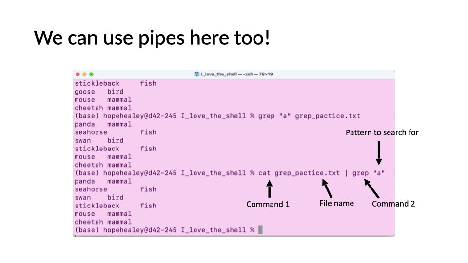

Figure 8: Pipe workflow step 1

## Pipe Workflow - Step 2

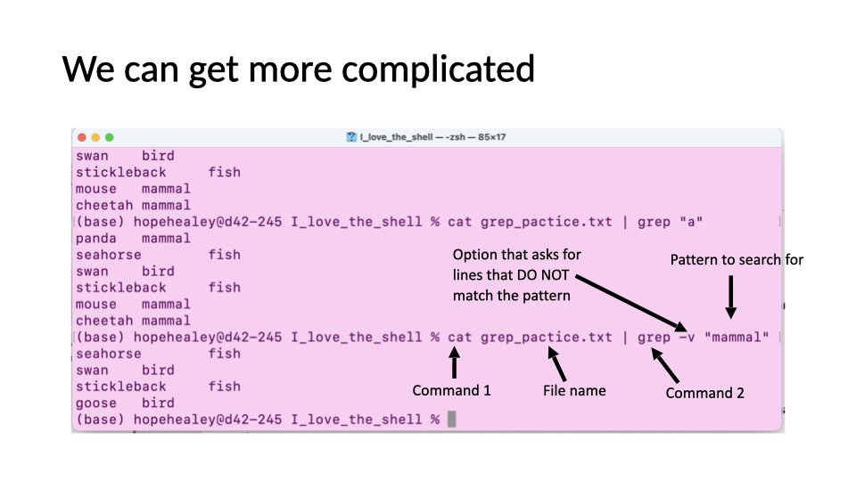

Figure 9: Pipe workflow step 2

## Pipe Workflow - Step 3

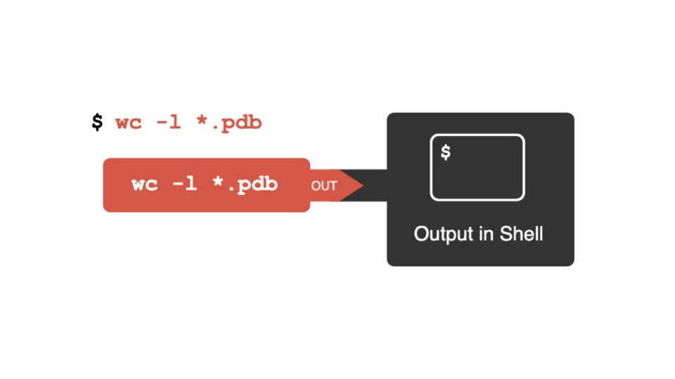

Figure 10: Pipe workflow step 3

## Pipe Workflow - Step 3 (SVG)

[figure not shown]

Pipe workflow step 3 - command output to shell

## Pipe Workflow - Step 4

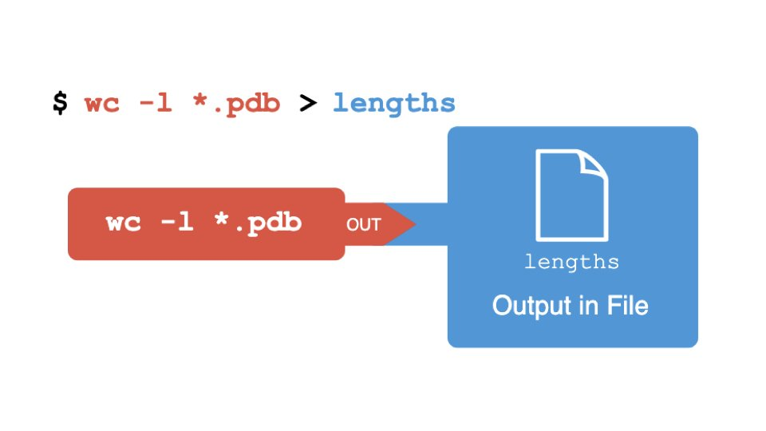

Figure 11: Pipe workflow step 4

## Pipe Workflow - Step 4 (SVG)

[figure not shown]

Pipe workflow step 4 - redirect output to file

## Pipe Workflow - Step 5

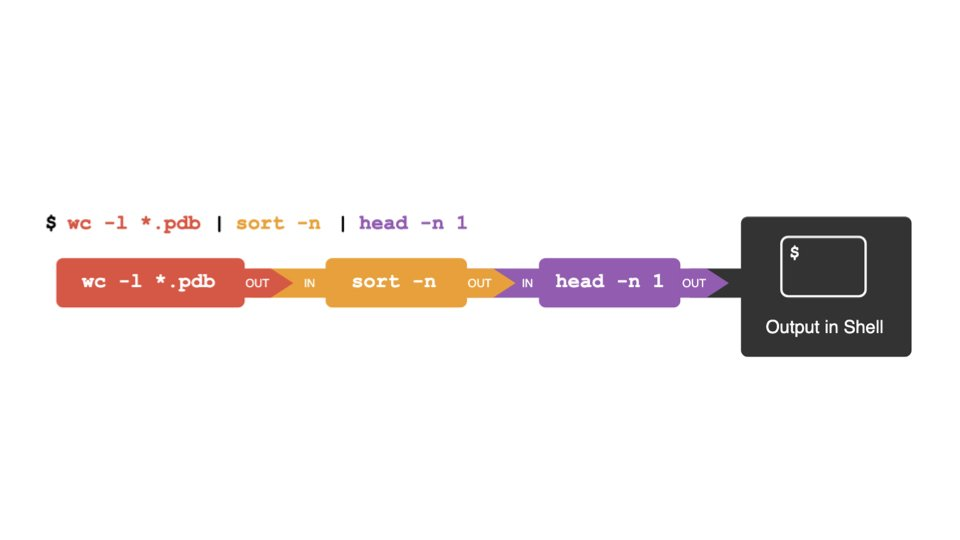

Figure 12: Pipe workflow step 5

## Pipe Workflow - Step 5 (SVG)

[figure not shown]

Pipe workflow step 5 - chained pipeline

## Visualization

- Output
- Code
- Interpretation
- Enhancement

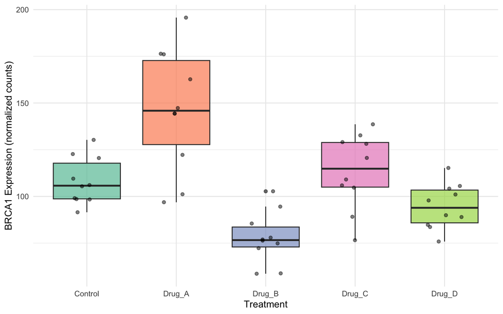

Figure 13: BRCA1 expression across treatment groups

```r
ggplot(gene_expression, aes(x = treatment, y = gene_BRCA1, fill = treatment)) +
  geom_boxplot(alpha = 0.7) +
  geom_jitter(width = 0.2, alpha = 0.5) +
  labs(x = "Treatment", y = "BRCA1 Expression (normalized counts)") +
  theme_minimal() +
  theme(legend.position = "none") +
  scale_fill_brewer(palette = "Set2")
```

- The boxplot reveals group differences in BRCA1 expression. Drug_A appears elevated compared to other treatments. The jittered points show individual observations, helping identify potential outliers or non-normal distributions within groups.
- Try adding `geom_violin()` instead of `geom_boxplot()` to see the full distribution shape, or use `facet_wrap(~treatment)` for separate panels.

## Statistical Test

- Output
- Code
- Interpretation
- Enhancement

ANOVA Results: BRCA1 Expression by Treatment

| term | df | sumsq | meansq | statistic | p.value |
| --- | --- | --- | --- | --- | --- |
| treatment | 4 | 26143.10 | 6535.7741 | 16.6582 | 0 |
| Residuals | 45 | 17655.58 | 392.3463 | NA | NA |

```r
anova_result <- aov(gene_BRCA1 ~ treatment, data = gene_expression)

# Using broom for tidy output
tidy(anova_result) |>
  kable(digits = 4, caption = "ANOVA Results")
```

- The one-way ANOVA tests whether mean BRCA1 expression differs across treatments. A significant p-value indicates at least one group differs. The `broom::tidy()` function converts the output to a clean data frame for reporting.
- For post-hoc pairwise comparisons, use `TukeyHSD(anova_result)` or `emmeans(anova_result, pairwise ~ treatment)` to identify which specific groups differ.

**Note**

The p-value indicates whether there are significant differences between groups.

## Cross-Referencing

This allows all elements within a Quarto document to be referenced from within the text, and then whenever you render the references are all updated automatically.

| Type | Label Prefix | Reference Syntax |
| --- | --- | --- |
| Figures | `#\| label: fig-` | `@fig-name` |
| Tables | `#\| label: tbl-` | `@tbl-name` |
| Equations | `{#eq-name}` | `@eq-name` |
| Sections | `{#sec-name}` | `@sec-name` |

## Rendering output Formats

Quarto can `render` to many formats:

**Documents:** HTML, PDF, Word (.docx), Markdown

**Presentations:** RevealJS (this presentation!), PowerPoint, Beamer

**Website:** HTML (all of our class material!)

```yaml
---
format:
  html: default
  pdf: default
  docx: default
---
```